# Classy: Data Insights Take Home Exam

## Author: Aaron Trefler

## Fall 2017 Data Science Internship Candidate

# Setup

```python
import matplotlib
import matplotlib.pyplot as plt
import numpy as np
import pandas as pd
import plotly
import plotly.offline as offline
import plotly.plotly as py
import seaborn as sns

from scipy.stats import bernoulli, expon, lognorm, multinomial, randint
from sklearn.linear_model import LinearRegression
from sklearn.metrics import r2_score
```

```python
# Script Variables
N = 50000 # data sample size
```

```python
# Plotting Setup
plt.rcParams['axes.titlesize'] = 18
plt.rcParams['axes.labelsize'] = 16
plt.rcParams['xtick.labelsize'] = 14
plt.rcParams['ytick.labelsize'] = 14
offline.init_notebook_mode()
```

# Access a Data Source

US state population data taken from the official US Census website. Data estimation accurate as of 7/1/2016.

- Source: https://www2.census.gov/programs-surveys/popest/datasets/2010-2016/state/asrh/
- Filename: scprc-est2016-18+pop-res.csv
- Dataset Description: https://www2.census.gov/programs-surveys/popest/technical-documentation/file-layouts/2010-2016/SCPRC-EST2016-18+POP-RES.pdf
- Data Estimation Methodology: https://www2.census.gov/programs-surveys/popest/technical-documentation/methodology/2010-2016/2016-natstcopr-meth.pdf

```python
# load in data
data_pop = 'scprc-est2016-18+pop-res.csv'
df_pop = pd.read_csv('../data/' + data_pop)

# extract relevant columns
df_pop_state = df_pop[['NAME', 'POPESTIMATE2016']]

# remove non-state entries
df_pop_state = df_pop_state[df_pop_state.NAME != 'United States']
df_pop_state = df_pop_state[df_pop_state.NAME != 'District of Columbia']
df_pop_state = df_pop_state[df_pop_state.NAME != 'Puerto Rico Commonwealth']
```

```python
print("Data Verification")
print("\nFirst 5 Entries:")
print(df_pop_state.head())
print("\nLast 5 Entries:")
print(df_pop_state.tail())
print("\nNumber of States:", df_pop_state.shape[0])
print("\nNaN or Missing Values")
print(np.sum(df_pop_state.isnull()))
```

```
Data Verification

First 5 Entries:
         NAME  POPESTIMATE2016
1     Alabama          4863300
2      Alaska           741894
3     Arizona          6931071
4    Arkansas          2988248
5  California         39250017

Last 5 Entries:
             NAME  POPESTIMATE2016
47       Virginia          8411808
48     Washington          7288000
49  West Virginia          1831102
50      Wisconsin          5778708
51        Wyoming           585501

Number of States: 50

NaN or Missing Values
NAME               0
POPESTIMATE2016    0
dtype: int64
```

# Generate Raw Data

## Age

Modeling approximations, estimates, and assumptions:

- Age is modeled as a uniform probability distribution from 0 to 54. Approximation based on US 2010 Census data (see Figure 1 below).
- Age is modeled as an exponential probability distribution (lambda = 0.05) for ages greater than 54. Approximation based on US 2010 Census data (see Figure 1 below).
- No ages greater than 113 were generated. If a value greater than 113 was generated, the value was discarded and re-sampled. Assumption based on an article published in the New York Post that stated that as of 02/09/17 the oldest person in America was 113.
- 72% of the population is estimated to be 54 or younger. Estimation taken from 2015 data provided by the Henry J. Kaiser Family Foundation.
- Young ages (i.e., 0-18) were allowed to be generated, as donations could be made in the names of these children but the money supplied by their parents, god parents, other family members, etc.

Sources:

- 2010 US Census, "Age and Sex Composition: 2010": https://www.census.gov/prod/cen2010/briefs/c2010br-03.pdf
- New York Post Article, "The oldest person in America has died": http://nypost.com/2017/02/09/the-oldest-person-in-america-has-died/
- The Henry J. Kaiser Family Foundation, "Population Distribution by Age": http://www.kff.org/other/state-indicator/distribution-by-age/?currentTimeframe=0&sortModel=%7B%22colId%22:%22Location%22,%22sort%22:%22asc%22%7D

Note:

- Continuous values sampled from the exponential distribution were converted to be discrete.

### Figure 1

[figure not shown]

```python
age_data = np.empty(N)
max_age = 113

# bernoulli parameter
p = .72

for i in range(N):
    # generate bernoulli outcome (1="54 and under", 0="over 54")
    x = bernoulli.rvs(p, size = 1)

    # generate appropriate age based on bernoulli outcome
    if (x == 1):
        # model "54 and under" as a discrete uniform distribution
        min_value = 0
        max_value = 54
        age_data[i] = randint.rvs(low=min_value, high=max_value+1, size=1)
    else:
        # model "over 54" as an exponential distribution
        decay_rate = .05;
        min_value = 55
        age_data[i] = np.floor(expon.rvs(loc=min_value, scale=1.0/decay_rate, size=1).astype(int))
        # re-sample if age drawn is greater than max_age
        while (age_data[i] > max_age):
            age_data[i] = np.floor(expon.rvs(loc=min_value, scale=1.0/decay_rate, size=1).astype(int))
```

## Gender

Modeling approximations, estimates, and assumptions:

- 50% of the population is estimated to be male, and the other 50% to be female. Approximation supported by 2010 US Census data, which stated that as of 2010 50.8% of the population was female and the rest were male.

Sources:

- 2010 US Census, "Age and Sex Composition: 2010": https://www.census.gov/prod/cen2010/briefs/c2010br-03.pdf

```python
p = .5
gender_data = bernoulli.rvs(p, size = N)
```

## Gift Size

Sources:

- Classy blog post, "Choosing the Right Giving Levels for Your Online Donation Form": https://www.classy.org/blog/choosing-the-right-giving-levels-for-your-online-donation-form/

```python
# Converts the mean and the standard deviation for a log-normal distribution over random variable X
# to the mean and standard deviation for the normal distribution of EXP(X)
#
# Code based on:
#   http://blogs.sas.com/content/iml/2014/06/04/simulate-lognormal-data-with-specified-mean-and-variance.html
def convert_mu_lognormal_parameters(mu_lognormal, sigma_lognormal):
    phi = np.sqrt(sigma_lognormal + mu_lognormal**2)
    mu = np.log(mu_lognormal**2/phi)
    sigma = np.sqrt(np.log(phi**2/mu_lognormal**2))
    return mu, sigma
```

```python
# choose gift size metrics
giftSize_avg = 126
giftSize_std = giftSize_avg**2.2

# create log-normal distribution
mu_lognormal = giftSize_avg
sigma_lognormal = giftSize_std
mu, sigma = convert_mu_lognormal_parameters(mu_lognormal, sigma_lognormal)

# generat values
giftSize_data = np.round(lognorm.rvs(s=sigma, scale=np.exp(mu), size=N), decimals=2)
```

## Billing State

Modeling approximations, estimates, and assumptions:

- Billing state was modeled as a multinomial distribution, with the probability of drawing a particular state proportional to the state's population.

```python
# calculate relative state populations
total_pop = np.sum(df_pop_state['POPESTIMATE2016'])
df_pop_state['POPESTIMATE2016_RELATIVE'] = df_pop_state['POPESTIMATE2016'] / total_pop
```

```python
# generate values from multinomial distribution over states
pvals = df_pop_state['POPESTIMATE2016_RELATIVE']
billingState_data = []
for i in range(N):
    x = np.array([multinomial.rvs(1, pvals, size=1)])
    x = x.squeeze().astype(bool)
    billingState_data.append(df_pop_state['NAME'][x].iloc[0])
```

## Create CSV File

```python
file = open('../data/generated_raw_data.csv', 'w')
file.write("Age," + "Gender (male=1)," + "Gift Size," + "Billing State"  + "\n")
for i in range(N):
    file.write(str(age_data[i]) + ", " +
               str(gender_data[i]) + ", " +
               str(giftSize_data[i]) + ", " +
               billingState_data[i] + "\n")
file.close()
```

# Summarize the Data

```python
df = pd.read_csv("../data/" + "generated_raw_data.csv")
```

## Average Gift Size by State

```python
print(np.round(df.groupby(by='Billing State').mean()['Gift Size'], 2))
```

```
Billing State
 Alabama           121.28
 Alaska            103.21
 Arizona           124.60
 Arkansas          132.98
 California        129.84
 Colorado          130.45
 Connecticut       132.67
 Delaware          116.18
 Florida           127.16
 Georgia           131.30
 Hawaii            143.37
 Idaho             122.36
 Illinois          121.95
 Indiana           136.07
 Iowa              157.14
 Kansas            119.34
 Kentucky          116.69
 Louisiana         139.12
 Maine             111.59
 Maryland          121.17
 Massachusetts     116.47
 Michigan          127.13
 Minnesota         120.29
 Mississippi       123.06
 Missouri          132.19
 Montana           155.81
 Nebraska          138.03
 Nevada            140.70
 New Hampshire     110.40
 New Jersey        125.92
 New Mexico        151.82
 New York          126.54
 North Carolina    127.31
 North Dakota      142.78
 Ohio              125.35
 Oklahoma          115.83
 Oregon            132.43
 Pennsylvania      127.23
 Rhode Island       94.70
 South Carolina    131.51
 South Dakota      124.69
 Tennessee         131.00
 Texas             128.25
 Utah              111.80
 Vermont           128.93
 Virginia          131.23
 Washington        128.30
 West Virginia     106.48
 Wisconsin         118.33
 Wyoming           121.63
Name: Gift Size, dtype: float64
```

## Average Per Capita Gift Size

```python
print(np.round(df['Gift Size'].mean(), 2))
```

```
127.43
```

## Average Gift Size by Gender

```python
print(np.round(df.groupby(by='Gender (male=1)').mean()['Gift Size'], 2))
```

```
Gender (male=1)
0    126.89
1    127.96
Name: Gift Size, dtype: float64
```

## Histogram of Gift Size

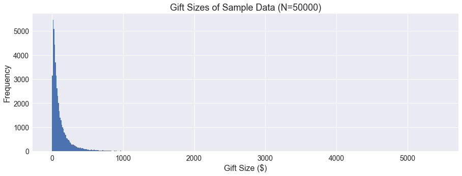

```
Mean:    127.43
Median:  66.38
Min:     0.89
Max:     5447.27
```

```python
plt.figure(figsize=(15,5))

data = df['Gift Size']
plt.hist(data, bins=500)
plt.title("Gift Sizes of Sample Data (N=" + str(N) + ")")
plt.xlabel("Gift Size ($)")
plt.ylabel("Frequency")

plt.show()

print("Mean:   ", np.round(df['Gift Size'].mean(), 2))
print("Median: ", np.round(df['Gift Size'].median(), 2))
print("Min:    ", np.round(df['Gift Size'].min(), 2))
print("Max:    ", np.round(df['Gift Size'].max(), 2))
```

Unimodal:

- The majority of the density is centered on the far left side of the histogram. Most values are densely centered around the median of \$66.38.

Skewed Right:

- Moving past the median along the extended right tail of the histogram we see an exponential decay in gift sizes, with the maximum gift size reaching \$5,447.27.

Reasons:

- The histogram has this shape because most people tend to give gifts of a modest amount (\$1 - \$500), whereas there is an ever decreasing amount of people who are capable and willing of making gifts of larger and larger values.
- Another fact that pushes the histogram towards having a positive skew is that it is impossible to make a negative gift, but possible to give gifts up to an arbitrarily large amount.

## Histogram of Age

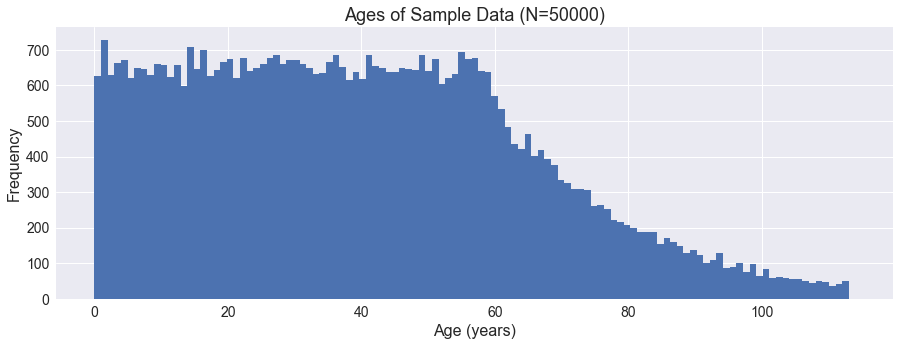

```
Mean:     39.48
Meadian:  38.0
Min:      0.0
Max:      113.0
```

```python
plt.figure(figsize=(15,5))

max_age = 114
data = df['Age']
plt.hist(data, range=(0,max_age), bins=max_age+1)
plt.title("Ages of Sample Data (N=" + str(N) + ")")
plt.xlabel("Age (years)")
plt.ylabel("Frequency")

plt.show()

print("Mean:    ", np.round(df['Age'].mean(), 2))
print("Meadian: ", np.round(df['Age'].median(), 2))
print("Min:     ", np.round(df['Age'].min(), 2))
print("Max:     ", np.round(df['Age'].max(), 2))
```

Unform (0 to late 50's):

- The histogram is effectively uniform from the values of 0 to late 50's.

Skewed Right:

- From the late 50's onward the histogram begins to decay exponentially stopping abruptly at a value of 113.

Reasons:

- The histogram is uniform from the values of 0 to late 50's because being born in any specific year is just as likely as any other.
- The exponential decay in the histogram's right tail is caused by the onset of life threatening health conditions that become exponentially more likely every year once you pass your late 50's.

Caveats:

- The modeling procedures used did not take into account generational effects, which would make the likelihood of sampling people being born in certain years more likely than others.
- The modeling assumptions used lead to a generative model that consistently over samples very senior ages (i.e., 90+). This potentially could be avoided by modeling very senior ages with a separate exponential distribution then was used for ages 55 to 89.

# Create Visualizations

```python
# Plots a selected measurment as heat-map across the 50 states of America.
#
# Code based on:
#   https://plot.ly/python/choropleth-maps/
def visualize_state_meas_map(df, meas, title, unit=''):

    for col in df.columns:
        df[col] = df[col].astype(str)

    df['text'] = df['Billing State'] + '<br>' + meas + ": " + df[meas]

    data = [ dict(
            type='choropleth',
            autocolorscale = True,
            locations = df['State Code'],
            z = df[meas].astype(float),
            locationmode = 'USA-states',
            text = df['text'],
            marker = dict(
                line = dict (
                    color = 'rgb(255,255,255)',
                    width = 2
                )
            ),
            colorbar = dict(
                title = unit
            )
        ) ]

    layout = dict(
            title = title,
            geo = dict(
                scope='usa',
                projection=dict( type='albers usa' ),
                showlakes = True,
                lakecolor = 'rgb(255, 255, 255)',
            ),
        )

    fig = dict(data=data, layout=layout)

    plotly.offline.iplot(fig, filename='d3-cloropleth-map')
```

## Average Gift Size by State

```python
# create DataFrame of average gift size by state
df_state_giftSize = \
    df.groupby(by='Billing State', as_index=False).mean()[['Billing State', 'Gift Size']]
df_state_giftSize['Gift Size'] = np.round(df_state_giftSize['Gift Size'], 2)

# add state codes to DataFrame (needed for plotly visualizations)
df_stateCodes = pd.read_csv('../data/state_codes.csv', header=None)
df_state_giftSize['State Code'] = df_stateCodes

# visualize
visualize_state_meas_map(df_state_giftSize.copy(), 'Gift Size', 'Average Gift Size by State',
                         'USD')
```

[interactive chart not shown]

## Number of Donations per State

```python
# create DataFrame of number of donations by state
df_state_numDonations = \
    df.groupby(by='Billing State', as_index=False).count()[['Billing State', 'Age']]
df_state_numDonations = \
    df_state_numDonations.rename(columns = {'Age': 'Number of Donations'})

# add state codes to DataFrame (needed for plotly visualizations)
df_stateCodes = pd.read_csv('../data/state_codes.csv', header=None)
df_state_numDonations['State Code'] = df_stateCodes

# visualize
visualize_state_meas_map(df_state_numDonations.copy(), 'Number of Donations',
                         'Number of Donations by State', 'Donations')
```

[interactive chart not shown]

# Build a Model

```python
df_lm = pd.DataFrame(data={
    'Population': df_pop_state['POPESTIMATE2016'].values,
    'Number of Donations': df_state_numDonations['Number of Donations'].values})
```

```python
# train linear model
lm = LinearRegression()
lm.fit(df_lm['Population'].values.reshape(-1, 1),
       df_lm['Number of Donations'].values.reshape(-1, 1))
b = lm.intercept_[0]
m = lm.coef_[0][0]

# calculate variance explained
y_true = df_lm['Number of Donations'].values.reshape(-1, 1)
y_pred = b + (m * df_lm['Population'].values)
r2 = r2_score(y_true, y_pred)
```

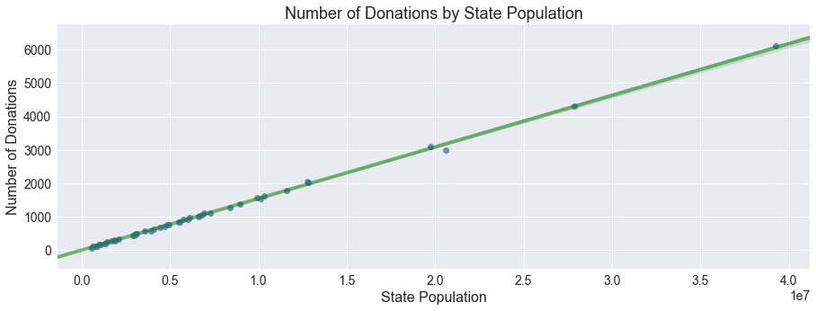

```
Percentage of Variance Explained (R-squared * 100) =  99.91
```

```python
plt.figure(figsize=(15,5))
sns.regplot(x="Population", y="Number of Donations", data=df_lm,
            line_kws={'color':"g", "alpha":0.5, "lw":4})
plt.title("Number of Donations by State Population")
plt.xlabel("State Population")
plt.show()

print("Percentage of Variance Explained (R-squared * 100) = ", round(r2 * 100, 2))
```

# General Caveats

- All generated variables in the analysis (i.e., age, gender, gift size, and billing state) were assumed to be independent from each other, which is clearly not the case. For example, knowing someone's age, gender, and billing state definitely gives you information useful in predicting/generating their gift size amount.